# DV_R-Assignment (FINAL)

## Part 1

1. **Data Inspection:**
- Install the following packages:

  ```r
  #load the following - suggested by Cook_Review to place it at the beginning:
   if (!require("ggplot2")) install.packages("ggplot2")
  library(ggplot2)
  if(!require("tibble")) install.packages("tibble")
  library(tibble)
  if (!require("reshape2")) install.packages("reshape2")
  library(reshape2)
  if (!require("plyr")) install.packages("plyr")
  library(plyr);
  if(!require("dplyr")) install.packages("dplyr")
  library(dplyr)
  ```

- Set working directory and open files:

  ```r
  setwd("~/Desktop/DV_R-Assignment")
  genotypes <- read.delim("fang_et_al_genotypes.txt")
  snp_pos <-read.delim("snp_position.txt")
  ```

- To inspect the files:
  - `file.info` = is used to determine size of file in bytes, whether the file is a directory, last status change and last access times, user ID of the file’s owner, username, group name, and other info.
  - `file.size` = to determine file size in bytes
  - `dim` = to determine number of rows and columns

    ```r
    summary(genotypes)
    summary(snp_pos)

    file.info("fang_et_al_genotypes.txt")
    file.info("snp_position.txt")

    file.size("fang_et_al_genotypes.txt")
    file.size("snp_position.txt")

    dim(genotypes)
    dim(snp_pos)
    ```

2. **Data processing:**
- First, need to parse the data out for groups:
  - Maize: ZMMIL, ZMMLR, and ZMMMR
  - Teosinte: ZMPBA, ZMPIL, and ZMPJA

    ```r
    maize_genotypes <- subset(genotypes, Group == "ZMMIL" | Group == "ZMMLR" | Group == "ZMMMR")

    teo_genotypes <- subset (genotypes, Group == "ZMPBA" | Group == "ZMPIL" | Group == "ZMPJA")
    ```

- Third, we need to transpose the data so that our columns in the `fang_et_al_genotypes.txt` file becomes our rows:

  ```r
  transposed_maize <- as.data.frame(t(maize_genotypes))
  transposed_teo <- as.data.frame(t(teo_genotypes))

  #Progress check:
  head(transposed_maize)
  head(transposed_teo)
  ```

- When looking at the data, column one doesn’t have name - need to rename it as “SNP_ID”:

  ```r
  names(transposed_maize) <- lapply(transposed_maize[1,], as.character) #this makes column one a character

  transposed_maize <- transposed_maize [-1,]

  names(transposed_teo) <- lapply(transposed_teo[1, ], as.character)
  transposed_teo <- transposed_teo[-1,]

  new_transposed_maize <- rownames_to_column(transposed_maize, var="SNP_ID")
  new_transposed_teo <- rownames_to_column(transposed_teo, var="SNP_ID")
  ```

- Next, sort transposed_maize and transposed_teosinte by SNP_ID:

  ```r
  sorted_maize <- arrange(new_transposed_maize, SNP_ID)
  sorted_teo<- arrange(new_transposed_teo, SNP_ID)
  ```

- Parse the snp data to only have SNP_ID, chromsome_ and position and sort by SNP_ID:

  ```r
  snp_pos_chrom <- snp_pos[, c("SNP_ID", "Chromosome", "Position")]
  sorted_snp_pos_chrom <- arrange(snp_pos_chrom, SNP_ID)
  ```

- Join sorted_maize genotypes and sorted_teosinte with the sorted_snp_pos_chrom data:

  ```r
  joined_maize <- merge(sorted_snp_pos_chrom,sorted_maize, by.x="SNP_ID", by.y="SNP_ID", all = TRUE)
  joined_teosinte <- merge(sorted_snp_pos_chrom,sorted_teo, by.x="SNP_ID", by.y="SNP_ID", all = TRUE)

  #Progress check:
  head(joined_teosinte)
  head(joined_maize)
  ```

- Extract data from each chromosome in maize and teosinte with increasing position with missing data indicated as “?”:

  ```r
  #sort increasing first:

  increase_pos_maize <- joined_maize[order(as.numeric(as.character(joined_maize$Position))),]

  increase_pos_teo <- joined_teosinte[order(as.numeric(as.character(joined_teosinte$Position))),]

  #at this point, you can set a working directory to save the files, if not, you can do so at the end of the entire run.

  for (i in 1:10) {
    maize_files_inc <- increase_pos_maize[increase_pos_maize$Chromosome == i,]
    #we can create a new CSV file for each chromosome
    write.csv(maize_files_inc, sprintf("Chr_%d_maize_increasing",i),row.names = F)
  }

  #at this point, you can set a working directory to save the files, if not, you can do so at the end of the entire run.

  for (i in 1:10){
    teosinte_files_inc<-increase_pos_teo[increase_pos_teo$Chromosome==i,]
    write.csv(teosinte_files_inc,sprintf("Chr_%d_teosinte_increasing",i),row.names = F)
  }
  ```

- Extract data from each chromosome in maize and teosinte with decreasing position with missing data indicated as “-”:

  ```r
  #sort decreasing first:
  decrease_pos_maize <- joined_maize[order(-as.numeric(as.character(joined_maize$Position))),]
  decrease_pos_teo <- joined_teosinte[order(-as.numeric(as.character(joined_teosinte$Position))),]

  #replace missing values as "-/-"
  decrease_pos_maize[decrease_pos_maize == "?/?"] <- "-/-"
  decrease_pos_teo [decrease_pos_teo == "?/?"] <- "-/-"

  #check progres
  head(decrease_pos_maize)
  head(decrease_pos_teo)

  #at this point, you can set a working directory to save the files, if not, you can do so at the end of the entire run.

  for (i in 1:10) {
    maize_files_dec <- decrease_pos_maize[decrease_pos_maize$Chromosome == i,]
    #we can create a new CSV file for each chromosome
    write.csv(maize_files_dec, sprintf("Chr_%d_maize_decreasing",i),row.names = F)
  }

  #at this point, you can set a working directory to save the files, if not, you can do so at the end of the entire run.
  for (i in 1:10){
    teosinte_files_decrease<-decrease_pos_teo[decrease_pos_teo$Chromosome==i,]
    write.csv(teosinte_files_decrease,sprintf("Chr_%d_teosinte_Decreasing",i),row.names = F)
  }
  ```

## Part 2

1. **Graphing Data - SNPs Per Chromosome:**
- Transpose the original genotypes data frame:

  ```r
  transposed_genotypes <- as.data.frame(t(genotypes))

  names(transposed_genotypes) <- lapply(transposed_genotypes[1,], as.character) #this makes column one a character

  transposed_genotypes <- transposed_genotypes[-1,]

  new_transposed_genotypes <- rownames_to_column(transposed_genotypes, var="SNP_ID")
  ```

- Sort new_transposed_genotypes with SNP_ID and join with sorted_snp_pos_chrom:

  ```r
  sorted_genotypes <- arrange(new_transposed_genotypes, SNP_ID)

  joined_genotypes <- merge(sorted_snp_pos_chrom,sorted_genotypes, by.x="SNP_ID", by.y="SNP_ID", all = TRUE)
  ```

- Graphing SNPs Per Chromosome and Distribution of SNPs per Chromosome:

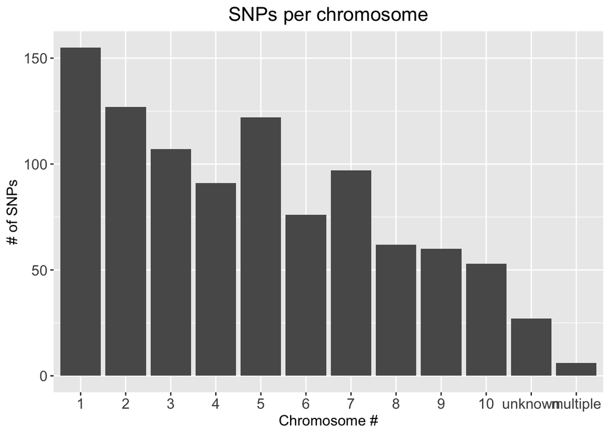

  ```r
  ggplot(data = joined_genotypes) +
    geom_bar(mapping = aes(x = Chromosome)) +
    scale_x_discrete(limits=c(1:10, "unknown", "multiple")) +
    ggtitle(label = "SNPs per chromosome") +
    xlab(label = "Chromosome #") +
    ylab(label = "# of SNPs") +
    theme(

      plot.title = element_text(hjust = 0.5, size = 16),
      axis.text = element_text(size = 12),
      axis.title = element_text(size = 12)
    )
  ```

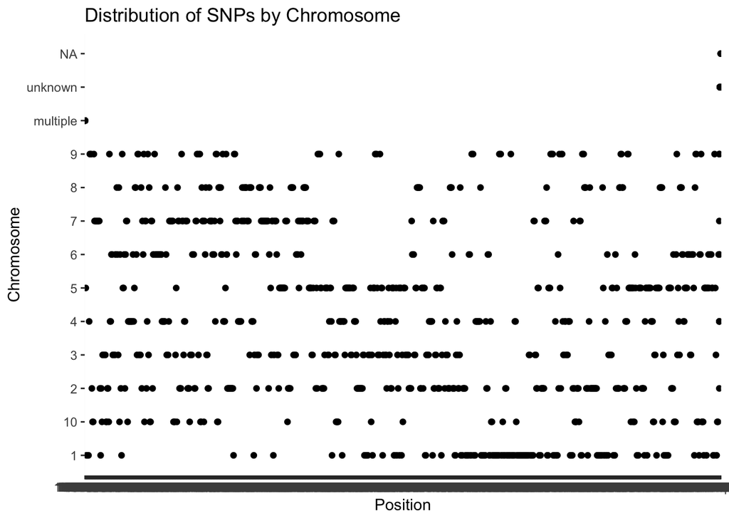

  ```r
  ggplot(data = joined_genotypes) +
    geom_point(mapping = aes(x=Position, y=Chromosome)) +
    ggtitle(label = "Distribution of SNPs by Chromosome")
  ```

2. **Graphing Data - Missing Data Heterozygosity:**
- Reorganize the data using `melt()`:

  ```r
  SNP_header <- colnames(genotypes)[-c(1:3)] #making a header for all SNP_IDs.
  m.genotype  <- melt(genotypes, measure.vars = SNP_header) #using melt function make our SNP_ID as rows

  colnames(m.genotype)[4] <- "SNP_ID" #renaming the 4th column from "variable" to SNP_ID

  m.genotype[ m.genotype == "?/?" ] = "N/A"
  ```

- Use `mutate()` to create new df with new column called “HOMOZYGOUS” with TRUE and FALSE:

  ```r
  m.genotype_new <-
    mutate(m.genotype, Homozygous = m.genotype$value=="A/A" | m.genotype$value=="C/C" | m.genotype$value=="G/G" | m.genotype$value=="T/T")

  #replace th TRUE and FALSE with "Homozygous", "Heterozygous" and "Missing"
  m.genotype_new$Homozygous [ m.genotype_new$Homozygous == "TRUE"] = "Homozygous"
  m.genotype_new$Homozygous [ m.genotype_new$Homozygous == "FALSE"] = "Heterozygous"
  m.genotype_new$Homozygous [ m.genotype_new$value == "N/A"] = "Missing"

  #progress report
  head(m.genotype_new)
  ```

- Plot by Sample_ID:

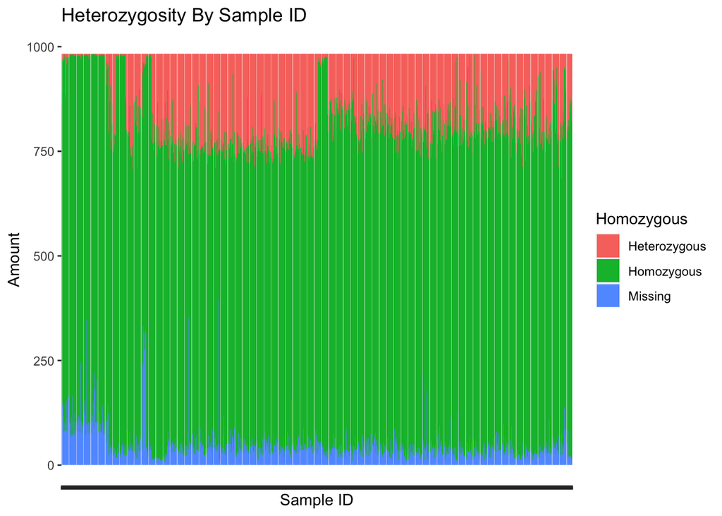

  ```r
  ggplot(data = m.genotype_new) +
    geom_bar(mapping = aes(x=Sample_ID, fill=Homozygous)) +
    scale_x_discrete(labels=NULL)+
    ggtitle(label = "Heterozygosity By Sample ID") +
    xlab(label = "Sample ID") +
    ylab(label = "Amount")
  ```

- Plot by Group:

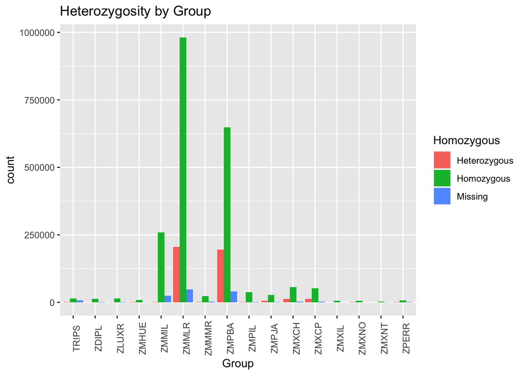

  ```r
  #changed to rotate x-axis labels 90 degree based off a suggestion by Sushma.

  ggplot(data = m.genotype_new) +
    geom_bar(mapping = aes(x=Group, fill=Homozygous), position="dodge") +
    ggtitle(label = "Heterozygosity by Group") +
    theme(axis.text.x = element_text(angle = 90))
  ```

3. **Graphing Data - Create your own plot: Amount of heterozygosity in each chromosome**

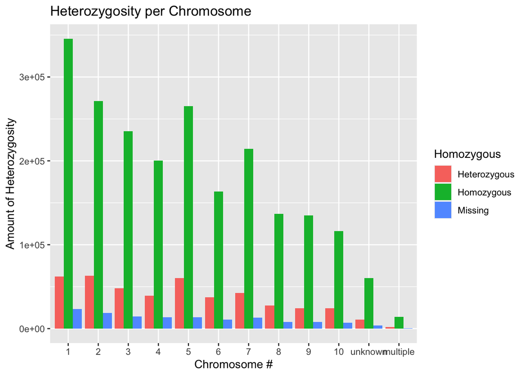

   ```r
   m.joined_geno <- merge(sorted_snp_pos_chrom, m.genotype_new, by.x="SNP_ID", by.y="SNP_ID", all = TRUE)


   ggplot(data= m.joined_geno) +
     geom_bar(mapping = aes(x = Chromosome, fill=Homozygous),position="dodge")+
     scale_x_discrete(limits=c(1:10, "unknown", "multiple")) +
     ggtitle(label = "Heterozygosity per Chromosome") +
     xlab(label = "Chromosome #") +
     ylab(label = "Amount of Heterozygosity")
   ```

Lastly, reorganize output files into their respective folders.